# Profit Strategies

### NYC Taxi Analysis

#### Summer 2015

Here I’ll investigate profit strategies for individual taxi drivers. My data set, libraries, etc. are all the same as in the Individual Taxis file.

Does more hours always mean more revenue?

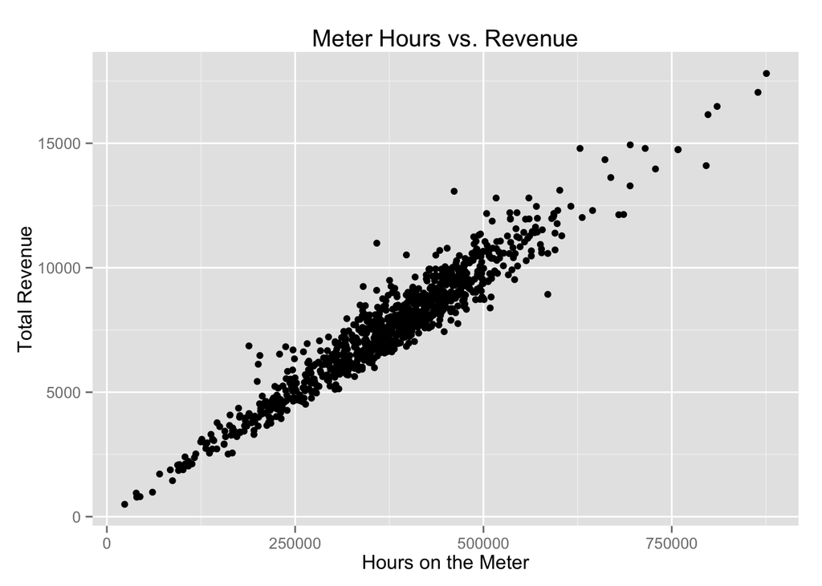

```r
strat_indiv_rev_time <- strat_indiv %>%
  group_by(hack_license) %>%
  summarize(total_time= sum(total_time), total_revenue = sum(total_revenue))

ggplot(strat_indiv_rev_time, aes(x = total_time, y = total_revenue)) +
  geom_point() +xlab("Hours on the Meter") + ylab("Total Revenue") +
  ggtitle("Meter Hours vs. Revenue")
```

Looks like the relationship is pretty linear (as expected). How about trips to revenue?

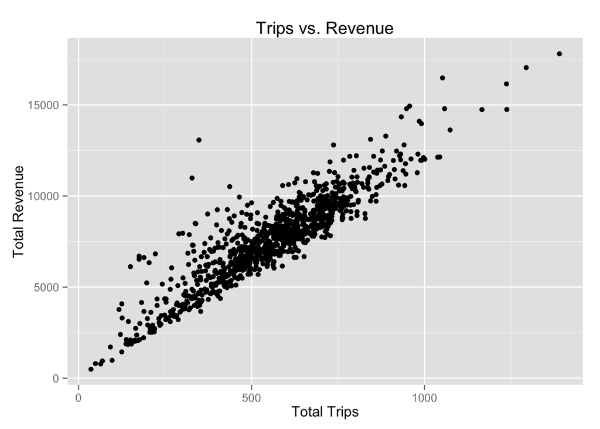

```r
strat_indiv_trips <- strat_indiv %>%
  group_by(hack_license) %>%
  summarize(total_revenue = sum(total_revenue), total_trips = sum(total_trips))

ggplot(strat_indiv_trips, aes(x = total_trips, y = total_revenue)) + geom_point() +
  xlab("Total Trips") + ylab("Total Revenue") + ggtitle("Trips vs. Revenue")
```

```r
fit <- lm(total_revenue ~ total_trips, data = strat_indiv_trips)
summary(fit)
```

```
##
## Call:
## lm(formula = total_revenue ~ total_trips, data = strat_indiv_trips)
##
## Residuals:
##     Min      1Q  Median      3Q     Max
## -2042.3  -687.0  -186.4   497.8  7828.3
##
## Coefficients:
##              Estimate Std. Error t value Pr(>|t|)
## (Intercept) 1264.7613   104.2876   12.13   <2e-16 ***
## total_trips   11.4334     0.1769   64.64   <2e-16 ***
## ---
## Signif. codes:  0 '***' 0.001 '**' 0.01 '*' 0.05 '.' 0.1 ' ' 1
##
## Residual standard error: 1038 on 942 degrees of freedom
## Multiple R-squared:  0.816,  Adjusted R-squared:  0.8158
## F-statistic:  4178 on 1 and 942 DF,  p-value: < 2.2e-16
```

This is again a pretty linear relationship. Can we find some other correlations in our data frame?

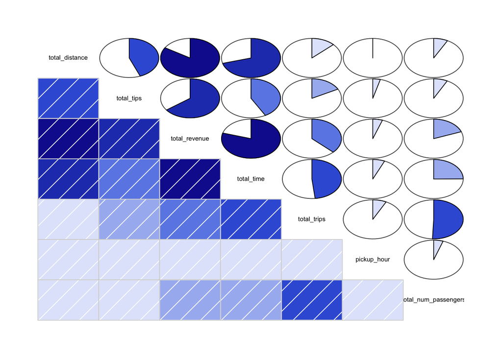

```r
corrgram(strat_indiv, order = TRUE, upper.panel = panel.pie)
```

These results aren’t entirely surprising: distance and time contribute significantly to revenue, as do number of trips.

Shall we try some machine learning, perhaps?

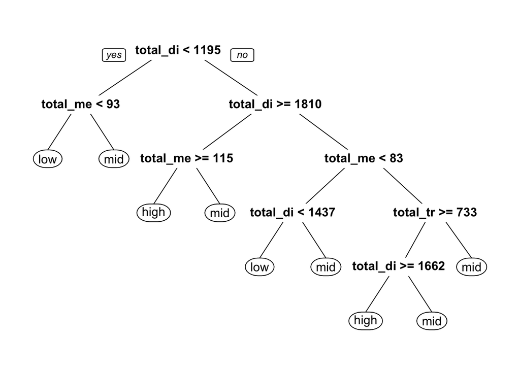

This begs the question, which path is the most lucrative?

```r
ml_best <- strat_indiv_ml %>%
  filter(rev_level == "high") %>%
  mutate(win_method = ifelse(total_distance >= 1218 & total_distance < 1819 &
                               total_meter_hours >= 132, "t_meter",
                        ifelse(total_distance >= 1819 & total_hours >=204, "t_hour",
                          ifelse(total_distance >= 1819 & total_hours < 204 & total_trips >= 603
                                 , "t_trip", "unknown")))) %>%
  filter(win_method!="unknown")

total_method <- ml_best %>%
  group_by(win_method) %>%
  summarize(count = n())
total_method
```

```
## Source: local data frame [3 x 2]
##
##   win_method count
## 1     t_hour   188
## 2    t_meter    14
## 3     t_trip     5
```

```r
total_rev <- ml_best %>%
  group_by(win_method) %>%
  summarize(total_revenue = sum(total_revenue)) %>%
  left_join(total_method, by = "win_method") %>%
  mutate(rev_per_driver = total_revenue/count)
total_rev
```

```
## Source: local data frame [3 x 4]
##
##   win_method total_revenue count rev_per_driver
## 1     t_hour    2040182.54   188      10852.035
## 2    t_meter     132912.69    14       9493.764
## 3     t_trip      48574.15     5       9714.830
```

[output not shown]

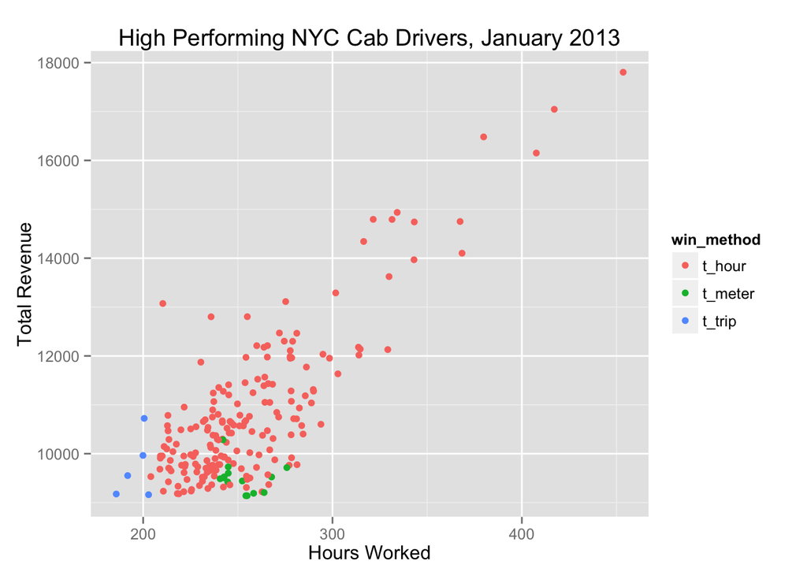

This graph is what we’d expect: the trip group spends fewer hours working, the meter group spends more hours working, and the hour group is much larger than the other two, accounting for the greater variance. It doesn’t seem that there’s one method that gives a particularly great return on investment (time).

With long trips in mind, look at airport pickups: what percentage of cab drivers spend time picking up at the airport? Does the percentage of total trips that pickup or dropoff at the airport have an effect on total revenue?

```r
airports <- taxi_strat %>%
  mutate(airport_name = ifelse(pickup_longitude > -73.889 & pickup_longitude < -73.855
                               & pickup_latitude > 40.767 & pickup_latitude < 40.786, "LGA",
                        ifelse(pickup_longitude > -73.823 & pickup_longitude < -73.748
                               & pickup_latitude > 40.621 & pickup_latitude < 40.663, "JFK",
                               "none")))
airport_indiv <- airports %>%
  group_by(hack_license, airport_name) %>%
  summarize(count = n(), total_revenue = sum(total_amount)) %>%
  spread(airport_name, count, fill = 0) %>%
  group_by(hack_license) %>%
  summarize(total_revenue = sum(total_revenue), JFK = sum(JFK), LGA = sum(LGA), none = sum(none)) %>%
  mutate(airport_trips = JFK + LGA, total = JFK + LGA + none, airport_percent = airport_trips/total,
         JFK_percent = JFK/airport_trips)

airport_indiv %>%
  filter(airport_percent == 0)
```

```
## Source: local data frame [98 x 9]
##
##                        hack_license total_revenue JFK LGA none
## 1  101D54B7A8CA21CD7DBCD4A0A3A76B5C       6985.35   0   0  610
## 2  15E2BAE77091CF17273E62E968F5CFA6       6712.06   0   0  493
## 3  173C13D67FAE4DABC5902B86384DE396       3452.79   0   0  276
## 4  205E3A3C2DCAF082C2BEDC05D2CB2D77       4754.81   0   0  388
## 5  21865A029F9C060780E18723E8A803DA       7916.05   0   0  608
## 6  23E6BE0A8359FA2A8D4C9D94983558BD       2915.52   0   0  214
## 7  2423BF109CDDFA44952B223C91B5C0FD       6455.90   0   0  550
## 8  25A23E1563B02D5768C3437A8F2AC854       8898.11   0   0  726
## 9  26E360A3257DFA700C6359FD5F1A6869      11071.39   0   0  896
## 10 2B4AF5B368B4EA9E7B432DA049F1DA19       8085.79   0   0  633
## ..                              ...           ... ... ...  ...
## Variables not shown: airport_trips (dbl), total (dbl), airport_percent
##   (dbl), JFK_percent (dbl)
```

About 10% of cabbies did not pick up anyone from an airport in January. Is there a revenue difference between picking up at JFK and picking up at LaGuardia?

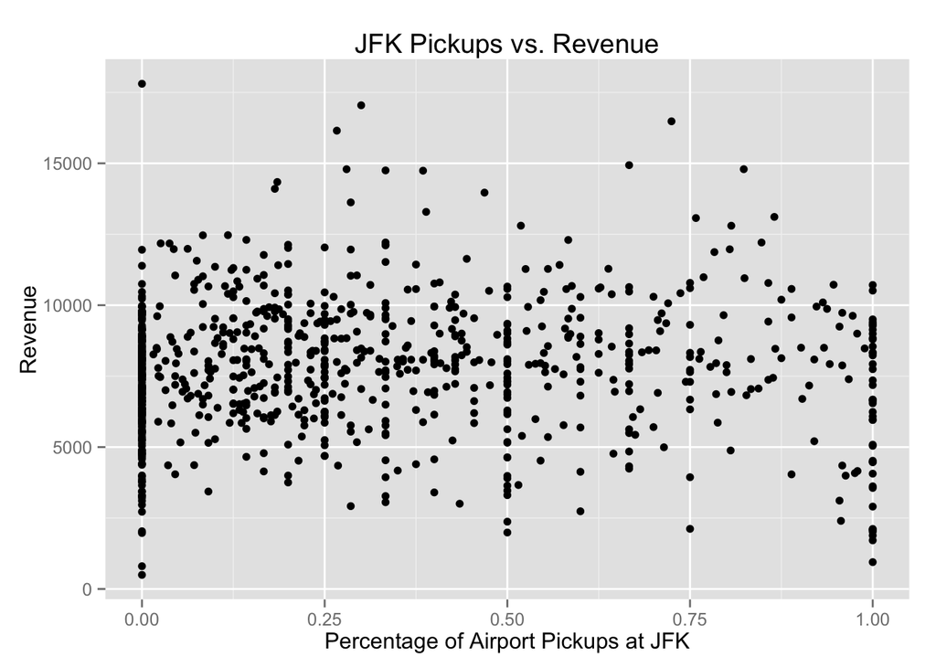

```r
ggplot(data = airport_indiv, aes(x = JFK_percent, y = total_revenue)) + geom_point() +
  xlab("Percentage of Airport Pickups at JFK") + ylab("Revenue") + ggtitle("JFK Pickups vs. Revenue")
```

There doesn’t seem to be much of a difference in revenue between the two airports (even though pickups from JFK are flat rate and pickups from LGA are not).

```
## geom_smooth: method="auto" and size of largest group is <1000, so using loess. Use 'method = x' to change the smoothing method.
```

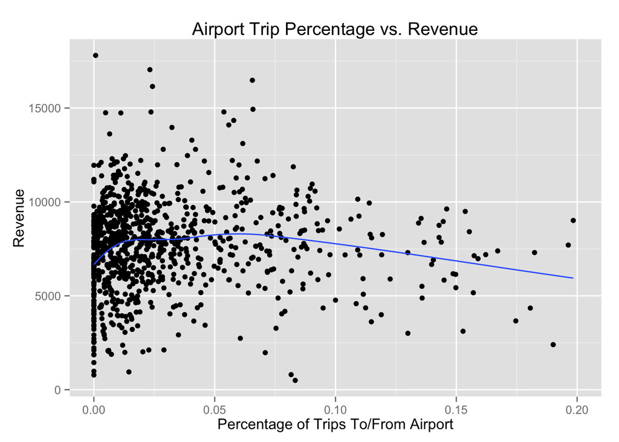

```r
ggplot(aes(x = airport_percent, y = total_revenue), data = airport_indiv) + geom_point() + xlim(0,.2) +
  geom_smooth(se = F) + xlab("Percentage of Trips To/From Airport") + ylab("Revenue") +
  ggtitle("Airport Trip Percentage vs. Revenue")
```

It doesn’t look like more airport pickups necessarily means more revenue. Were there any days in January 2013 that had an especially high number of airport pickups?

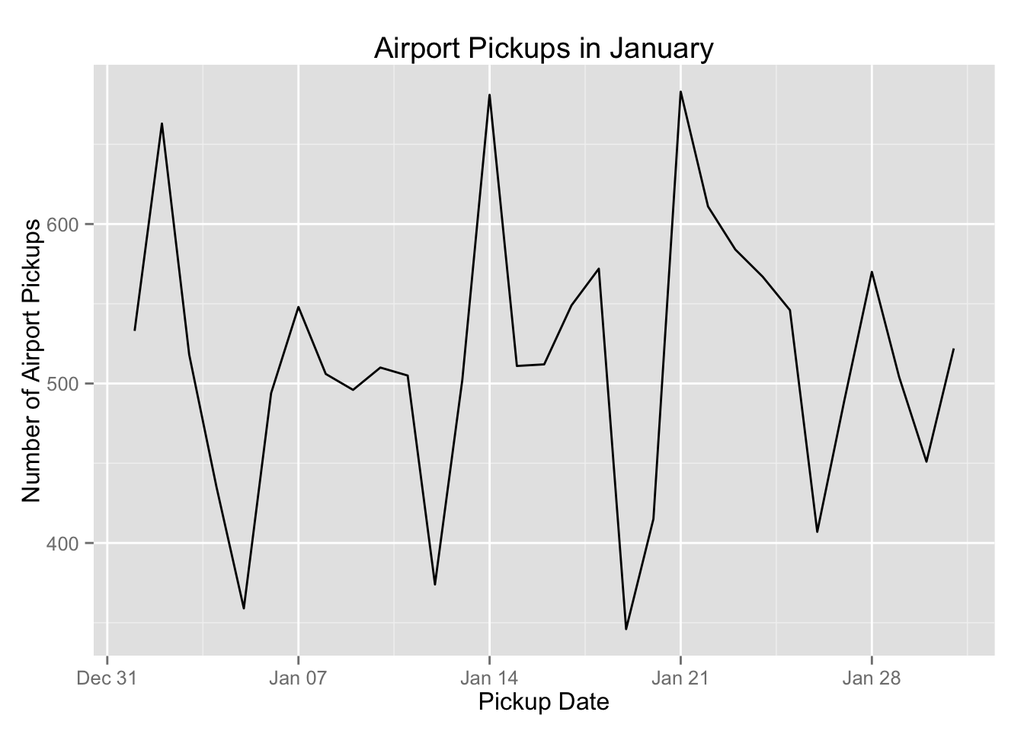

```r
airport_date <- airports %>%
  group_by(pickup_date, airport_name) %>%
  summarize(count = n()) %>%
  spread(airport_name, count) %>%
  mutate(airport = JFK + LGA)

ggplot(data = airport_date, aes(x = pickup_date, y = airport)) + geom_line() +
  xlab("Pickup Date") + ylab ("Number of Airport Pickups") + ggtitle("Airport Pickups in January")
```

We can see that Mondays are big airport pickup days, perhaps because many people fly on Mondays or because overall taxi traffic is much lower on Mondays, so more cabbies flock to the airports.

```r
airport_hours <- airports %>%
  filter(airport_name!="none") %>%
  group_by(pickup_hour) %>%
  summarize(count = n(), total_revenue = sum(total_amount))

bp <- ggplot(data = airport_hours)
bp_count <- bp + geom_line(aes(x = pickup_hour, y = count)) + ggtitle("Airport Pickup Counts")
bp_rev <- bp + geom_line(aes(x = pickup_hour, y = total_revenue)) + ggtitle("Airport Pickup Revenue")
```

Looks like prime time for an airport pickup is around 4pm. Is this the case for pickups in general?

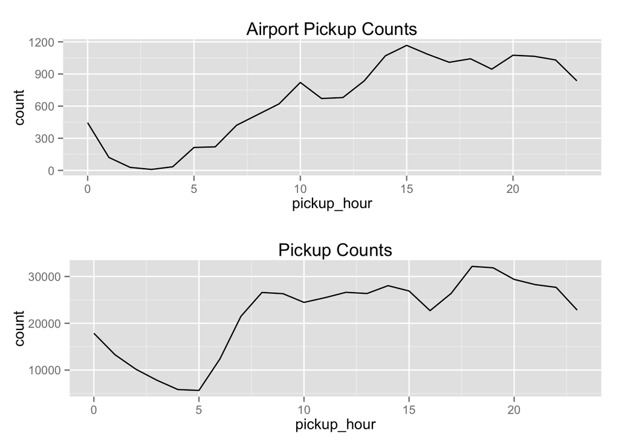

```r
times <- taxi_strat %>%
  group_by(pickup_hour) %>%
  summarize(count = n(), total_revenue = sum(total_amount))

bp2 <- ggplot(data = times)
bp2_count <- bp2 + geom_line(aes(x = pickup_hour, y = count)) + ggtitle("Pickup Counts")
bp2_rev <- bp2 + geom_line(aes(x = pickup_hour, y = total_revenue)) + ggtitle("Pickup Revenue")

grid.arrange(bp_count, bp2_count, ncol = 1)
```

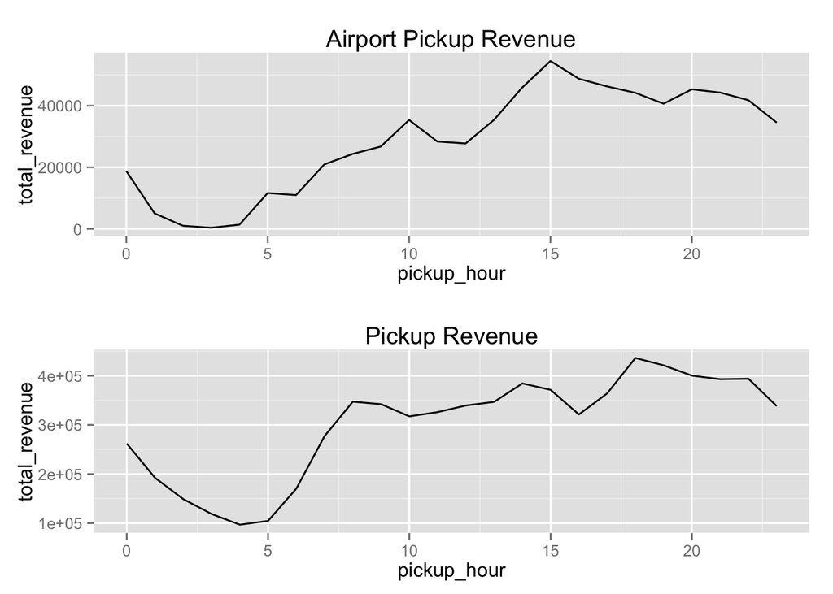

```r
grid.arrange(bp_rev, bp2_rev, ncol = 1)
```

Notice that general pickups seem to dip at around 4pm, while airport pickups rise. So, the few cabbies that do pickups at 4pm go to the airport. We see a similar shape with the revenue graphs.

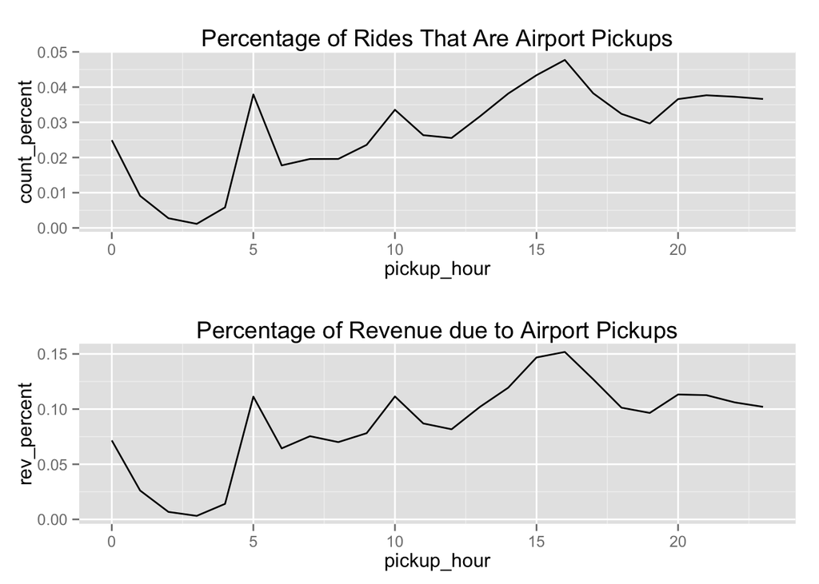

```r
airport_percent <- airport_hours %>%
  left_join(times, by = "pickup_hour") %>%
  mutate(count_percent = count.x/count.y, rev_percent = total_revenue.x/total_revenue.y)

bp3 <- ggplot(data = airport_percent)
bp3_count <- bp3 + geom_line(aes(x = pickup_hour, y = count_percent)) +
  ggtitle("Percentage of Rides That Are Airport Pickups")
bp3_rev <- bp3 + geom_line(aes(x = pickup_hour, y = rev_percent)) +
  ggtitle("Percentage of Revenue due to Airport Pickups")

grid.arrange(bp3_count, bp3_rev)
```

These two graphs tell a similar story: at 5am and 4pm, we see an increase in the percentage of pickups at airports. The 5am peak is understandable: there are probably fewer potential passengers on the streets so early, so the few flights that get in early may provide a more attractive market than the NYC streets. The 4pm peak is a little more surprising, however. Could it be that cabbies working the morning shift want to get one last long (and lucrative) trip in before the end of their shift, so they pick up from the airport? Not sure what to make of this as of yet.